# Matrices, Arrays, and Connect 4

Student edition

# 1 **Introduction to the Connect 4 Game**

## 1.1 **What is Connect 4?**

Connect 4 is a classic two-player strategy game where players take turns dropping their pieces into a **6-row by 7-column grid**. The goal is to be the first to align four of your pieces **horizontally, vertically, or diagonally**.

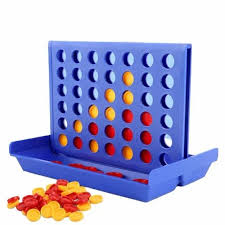

### 1.1.1 **Game Rules:**

1. Players take turns dropping pieces into one of the seven columns.
2. The piece falls to the lowest available row in the selected column.
3. The first player to align **four pieces in a row, column, or diagonal wins**.
4. If the board is full and no player has won, the game ends in a **draw**.

[Game Rules Explained](https://youtu.be/ylZBRUJi3UQ?si=md-aQDpmZmJFL-vy)

## 1.2 **Why Are We Implementing This in R?**

Throughout this course, we will progressively build the Connect 4 game, integrating concepts we learn in R along the way. This will allow us to:

- **Practice fundamental R concepts** in an engaging way.
- **Apply matrices, arrays, and data structures** in a more practical scenario.
- **Develop functions and game logic step-by-step** as we learn about control structures and loops.

## 1.3 **How Will We Implement It?**

We will break the game code over **several weeks** into stages, aligned with our class topics:

1. **Representing the Game Board** (Current Topic: Matrices & Arrays)
   - We will use a **6x7 matrix** to store the board state.
   - Empty slots will be represented as `0`, Player 1 as `1`, and Player 2 as `2`.
2. **Dropping a Piece into a Column**
   - We will simulate a player dropping a piece into the board.
   - The piece should “fall” to the lowest available row in the selected column.
3. **Checking for a Win Condition**
   - We will write logic to check if a player has connected four pieces.
4. **Adding Player Turns and Game Loop**
   - We will implement a turn-based game loop.

## 1.4 **Our First Step: The Game Board as a Matrix**

In R, we can represent the Connect 4 board as a matrix:

```r
# Create a 6x7 empty board
board <- matrix(0, nrow = 6, ncol = 7)
print(board)
```

```
##      [,1] [,2] [,3] [,4] [,5] [,6] [,7]
## [1,]    0    0    0    0    0    0    0
## [2,]    0    0    0    0    0    0    0
## [3,]    0    0    0    0    0    0    0
## [4,]    0    0    0    0    0    0    0
## [5,]    0    0    0    0    0    0    0
## [6,]    0    0    0    0    0    0    0
```

This matrix structure allows us to:

- Modify elements to simulate piece placements.
- Iterate through rows and columns to check for wins.
- Easily update the board state after each move.

# 2 Matrices and Arrays

A *matrix* is simply several vectors stored together. Whereas the size of a vector is described by its length, the **size** of a matrix is specified by a number of rows and a number of columns. You can also create higher-dimensional structures that are referred to as *arrays*.

## 2.1 Defining a Matrix

The matrix is an important mathematical construct, and it’s essential to many statistical methods. For example, the ordinary least squares employs matrix calculations. You typically describe a matrix $A$ as an $m \times n$ matrix; that is, $A$ will have exactly $m$ rows and $n$ columns.

This means $A$ will have a total of $mn$ entries, with each entry $a_{i,j}$ having a unique position given by its specific row $(i = 1, 2, \dots, m)$ and column $(j = 1, 2, \dots, n)$.

A matrix is a structured arrangement of numbers in rows and columns, typically represented as:

$$A =
\begin{bmatrix}
a_{1,1} & a_{1,2} & \dots & a_{1,n} \\
a_{2,1} & a_{2,2} & \dots & a_{2,n} \\
\vdots & \vdots & \ddots & \vdots \\
a_{m,1} & a_{m,2} & \dots & a_{m,n}
\end{bmatrix}$$

### 2.1.1 Creating a Matrix in R

In R, matrices are created using the `matrix()` function by supplying a vector of data and specifying the number of rows (`nrow`) and columns (`ncol`):

```r
A <- matrix(data = c(-3, 2, 893, 0.17), nrow = 2, ncol = 2)
A
```

```
##      [,1]   [,2]
## [1,]   -3 893.00
## [2,]    2   0.17
```

This results in:

```
      [,1]    [,2]
[1,]   -3   893.00
[2,]    2     0.17
```

Ensure that the number of elements in the vector matches `nrow * ncol`. If `nrow` and `ncol` are not provided, R defaults to a single-column matrix.

## 2.2 Filling Direction

By default, R fills matrices *column-wise*, meaning data is entered down each column before moving to the next. You can control this behavior using the `byrow` argument.

To create a 3×2 matrix filled *column-wise* (default):

```r
matrix(data = c(1,2,3,4,5,6), nrow = 3, ncol = 2, byrow = FALSE)
```

```
##      [,1] [,2]
## [1,]    1    4
## [2,]    2    5
## [3,]    3    6
```

Output:

```
     [,1] [,2]
[1,]    1    4
[2,]    2    5
[3,]    3    6
```

To fill *row-wise*, set `byrow = TRUE`:

```r
matrix(data = c(1,2,3,4,5,6), nrow = 3, ncol = 2, byrow = TRUE)
```

```
##      [,1] [,2]
## [1,]    1    2
## [2,]    3    4
## [3,]    5    6
```

Output:

```
     [,1] [,2]
[1,]    1    2
[2,]    3    4
[3,]    5    6
```

By default, R assumes `byrow = FALSE`. Adjust this argument to match the intended data structure.

## 2.3 Row and Column Bindings

To construct a matrix from multiple vectors of equal length, use:

- `rbind()` to stack vectors as **rows**.
- `cbind()` to arrange vectors as **columns**.

For example, using `rbind()`:

```r
rbind(c(1,2,3), c(4,5,6))
```

```
##      [,1] [,2] [,3]
## [1,]    1    2    3
## [2,]    4    5    6
```

Output:

```
     [,1] [,2] [,3]
[1,]    1    2    3
[2,]    4    5    6
```

Here, `rbind()` stacks the vectors as rows, maintaining the given order.

Alternatively, using `cbind()`:

```r
cbind(c(1,4), c(2,5), c(3,6))
```

```
##      [,1] [,2] [,3]
## [1,]    1    2    3
## [2,]    4    5    6
```

Output:

```
     [,1] [,2] [,3]
[1,]    1    2    3
[2,]    4    5    6
```

This binds vectors as columns, forming a matrix where each vector becomes a column.